# R Notebook: #66daysof(health)data - Day Three

Measures of Central Tendency, Power, Confidence Intervals & doing Hypothesis Testing using the Cleveland Heart Attack Data

```r
library(tidyverse)
# Read in Heart Attacks data set
heart <- read_csv(
  "Data/heart.csv",
  col_types = list(
    age = col_integer(),
    sex = col_number(),
    cp = col_number(),
    trtbps = col_integer(),
    chol = col_integer(),
    fbs = col_logical(),
    restecg = col_number(),
    thalachh = col_integer(),
    exng = col_logical(),
    oldpeak = col_double(),
    slp = col_number(),
    caa = col_integer(),
    thall = col_number(),
    output = col_logical()
  )
)

spec(heart)
head(heart, 10)
```

| age | sex | cp | trtbps | chol | fbs | restecg | thalachh | exng | oldpeak | slp | caa | thall | output |
| --- | --- | --- | --- | --- | --- | --- | --- | --- | --- | --- | --- | --- | --- |
| 63 | 1 | 3 | 145 | 233 | TRUE | 0 | 150 | FALSE | 2.3 | 0 | 0 | 1 | TRUE |
| 37 | 1 | 2 | 130 | 250 | FALSE | 1 | 187 | FALSE | 3.5 | 0 | 0 | 2 | TRUE |
| 41 | 0 | 1 | 130 | 204 | FALSE | 0 | 172 | FALSE | 1.4 | 2 | 0 | 2 | TRUE |
| 56 | 1 | 1 | 120 | 236 | FALSE | 1 | 178 | FALSE | 0.8 | 2 | 0 | 2 | TRUE |
| 57 | 0 | 0 | 120 | 354 | FALSE | 1 | 163 | TRUE | 0.6 | 2 | 0 | 2 | TRUE |
| 57 | 1 | 0 | 140 | 192 | FALSE | 1 | 148 | FALSE | 0.4 | 1 | 0 | 1 | TRUE |
| 56 | 0 | 1 | 140 | 294 | FALSE | 0 | 153 | FALSE | 1.3 | 1 | 0 | 2 | TRUE |
| 44 | 1 | 1 | 120 | 263 | FALSE | 1 | 173 | FALSE | 0.0 | 2 | 0 | 3 | TRUE |
| 52 | 1 | 2 | 172 | 199 | TRUE | 1 | 162 | FALSE | 0.5 | 2 | 0 | 3 | TRUE |
| 57 | 1 | 2 | 150 | 168 | FALSE | 1 | 174 | FALSE | 1.6 | 2 | 0 | 2 | TRUE |

```r
# Recode Factors

heart$sex <- as.factor(heart$sex)
levels(heart$sex) <- c('FEMALE', 'MALE')

heart$cp <- factor(heart$cp, levels=c('3', '2', '1', '0'))
levels(heart$cp) <- c('ASYMPT', 'NON-ANG PAIN', 'ATYP ANG', 'TYP ANG')

heart$restecg <- as.factor(heart$restecg)
levels(heart$restecg) <- c('NORM', 'ABN ST-T', 'LVH')

heart$slp <- factor(heart$slp, levels=c('1', '2', '0'))
levels(heart$slp) <- c('FLAT', 'DOWNSLP', 'UPSLP')

# Can't translate this one because I can't find a data dictionary that shows what these codes (0-3) mean
heart$thall <- as.factor(heart$thall)
head(heart, 10)
```

| age | sex | cp | trtbps | chol | fbs | restecg | thalachh | exng | oldpeak | slp | caa | thall | output |
| --- | --- | --- | --- | --- | --- | --- | --- | --- | --- | --- | --- | --- | --- |
| 63 | MALE | ASYMPT | 145 | 233 | TRUE | NORM | 150 | FALSE | 2.3 | UPSLP | 0 | 1 | TRUE |
| 37 | MALE | NON-ANG PAIN | 130 | 250 | FALSE | ABN ST-T | 187 | FALSE | 3.5 | UPSLP | 0 | 2 | TRUE |
| 41 | FEMALE | ATYP ANG | 130 | 204 | FALSE | NORM | 172 | FALSE | 1.4 | DOWNSLP | 0 | 2 | TRUE |
| 56 | MALE | ATYP ANG | 120 | 236 | FALSE | ABN ST-T | 178 | FALSE | 0.8 | DOWNSLP | 0 | 2 | TRUE |
| 57 | FEMALE | TYP ANG | 120 | 354 | FALSE | ABN ST-T | 163 | TRUE | 0.6 | DOWNSLP | 0 | 2 | TRUE |
| 57 | MALE | TYP ANG | 140 | 192 | FALSE | ABN ST-T | 148 | FALSE | 0.4 | FLAT | 0 | 1 | TRUE |
| 56 | FEMALE | ATYP ANG | 140 | 294 | FALSE | NORM | 153 | FALSE | 1.3 | FLAT | 0 | 2 | TRUE |
| 44 | MALE | ATYP ANG | 120 | 263 | FALSE | ABN ST-T | 173 | FALSE | 0.0 | DOWNSLP | 0 | 3 | TRUE |
| 52 | MALE | NON-ANG PAIN | 172 | 199 | TRUE | ABN ST-T | 162 | FALSE | 0.5 | DOWNSLP | 0 | 3 | TRUE |
| 57 | MALE | NON-ANG PAIN | 150 | 168 | FALSE | ABN ST-T | 174 | FALSE | 1.6 | DOWNSLP | 0 | 2 | TRUE |

```r
# Measures of Central Tendency

summary(heart)
```

```
##       age            sex                 cp          trtbps
##  Min.   :29.00   FEMALE: 96   ASYMPT      : 23   Min.   : 94.0
##  1st Qu.:47.50   MALE  :207   NON-ANG PAIN: 87   1st Qu.:120.0
##  Median :55.00                ATYP ANG    : 50   Median :130.0
##  Mean   :54.37                TYP ANG     :143   Mean   :131.6
##  3rd Qu.:61.00                                   3rd Qu.:140.0
##  Max.   :77.00                                   Max.   :200.0
##       chol          fbs              restecg       thalachh        exng
##  Min.   :126.0   Mode :logical   NORM    :147   Min.   : 71.0   Mode :logical
##  1st Qu.:211.0   FALSE:258       ABN ST-T:152   1st Qu.:133.5   FALSE:204
##  Median :240.0   TRUE :45        LVH     :  4   Median :153.0   TRUE :99
##  Mean   :246.3                                  Mean   :149.6
##  3rd Qu.:274.5                                  3rd Qu.:166.0
##  Max.   :564.0                                  Max.   :202.0
##     oldpeak          slp           caa         thall     output
##  Min.   :0.00   FLAT   :140   Min.   :0.0000   0:  2   Mode :logical
##  1st Qu.:0.00   DOWNSLP:142   1st Qu.:0.0000   1: 18   FALSE:138
##  Median :0.80   UPSLP  : 21   Median :0.0000   2:166   TRUE :165
##  Mean   :1.04                 Mean   :0.7294   3:117
##  3rd Qu.:1.60                 3rd Qu.:1.0000
##  Max.   :6.20                 Max.   :4.0000
```

```r
nrow(heart)
```

```
## [1] 303
```

Yesterday, we calculated power and did hypothesis testing using Pearson’s R correlation and two-sample t-testing.

Today, let’s shift gears a bit, and move in another direction. Let’s do some categorical analysis with Chi-Sq and CMH testing!

First, let’s try a Chi-Sq test to see if there may be a difference in relationship between people with exercise-induced angina (exng) and coronary artery disease (output) vs. those without.

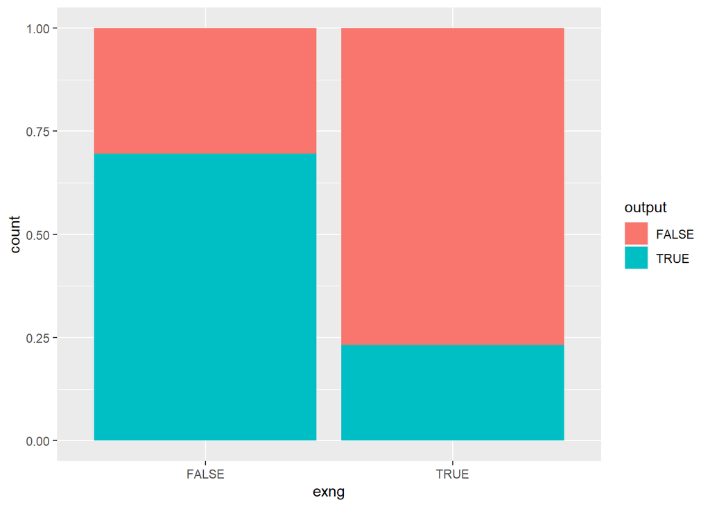

```r
# A preliminary plot, to get a look at the data

ggplot(heart) +
  aes(x = exng, fill = output) +
  geom_bar(position = "fill")
```

It looks like the relationship between exercise-induced angina and vessel narrowing isn’t what I expected!

```r
# Create a table with the needed variables.
heart.data = table(heart$exng, heart$output)
print(heart.data)
```

```
##
##         FALSE TRUE
##   FALSE    62  142
##   TRUE     76   23
```

```r
# Perform the Chi-Square test.
print(chisq.test(heart.data))
```

```
##
##  Pearson's Chi-squared test with Yates' continuity correction
##
## data:  heart.data
## X-squared = 55.945, df = 1, p-value = 7.454e-14
```

```r
# Calculate the critical value.
writeLines("The critical value is:")
```

```
## The critical value is:
```

```r
qchisq(0.05, 1)
```

```
## [1] 0.00393214
```

On the left side of the table, we have Exercise-Induced Angina T/F, and on the top of the table, we have Coronary Artery Disease, T/F.

Of those **without** exercise-induced angina, 70% had coronary artery disease! Of those with exercise-induced angina, only 23% had coronary artery disease! So, while there appears to be a significant effect size (55.95, which is above the critical value of 0.004) and p-value <.0001, the direction of the relationship isn’t what I would have expected.

Now, let’s calculate the power, with 1 df:

```r
library(pwr)
pwr.chisq.test(w=0.2, N=303, df=1, sig.level=0.05)
```

```
##
##      Chi squared power calculation
##
##               w = 0.2
##               N = 303
##              df = 1
##       sig.level = 0.05
##           power = 0.9359222
##
## NOTE: N is the number of observations
```

Having 303 rows, we can detect a small (0.2) effect size with 93.6% power at alpha=0.05.

This means that we only have a 6.4% chance of failing to reject the NULL hypothesis if the NULL hypothesis is FALSE (making a Type II error).

And, since we set alpha = 0.05, we have a 5% chance of rejecting the NULL hypothesis when it is actually TRUE (making a Type I error).

```r
library(pwr)

pwr.chisq.test(w=0.2, df=1, power=0.80, sig.level=0.05)
```

```
##
##      Chi squared power calculation
##
##               w = 0.2
##               N = 196.2215
##              df = 1
##       sig.level = 0.05
##           power = 0.8
##
## NOTE: N is the number of observations
```

To achieve 80% power and detect a small effect (0.2), we need at least 197 samples.

Now, let’s apply The Cochran-Mantel-Haenszel test by performing the same chi-sq test again, but breaking down the results by sex.

H0: There is NO significant three way interaction between exercise-induced angina, coronary artery disease and sex. There is no significant confounding influence of sex on the relationship between exercise-induced angina and CAD / vessel narrowing.

HA: There IS a significant three way interaction between exercise-induced angina, coronary artery disease and sex. Exercise-induced angina and coronary artery disease are not independent within each level of sex. There IS a significant confounding influence of sex on the relationship between exercise-induced angina and CAD / vessel narrowing.

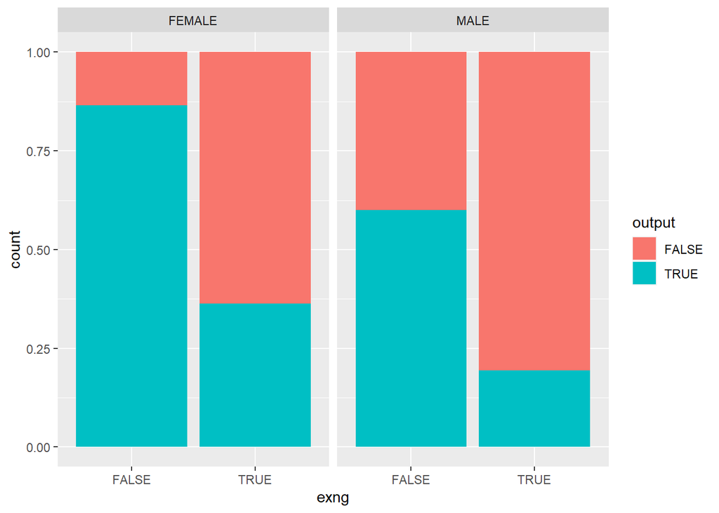

```r
ggplot(heart) +
  aes(x = exng, fill = output) +
  geom_bar(position = "fill") +
  facet_wrap(~sex)
```

Surprisingly, it looks like females were more likely to have CVD overall (OUTPUT=TRUE) in this data set, but those **without** exercise-induced angina were **much** more likely to have CVD than males without the same.

```r
library(vcd)
library(rcompanion)
heart.table <- table(heart$exng, heart$output, heart$sex)
heart.table
```

```
## , ,  = FEMALE
##
##
##         FALSE TRUE
##   FALSE    10   64
##   TRUE     14    8
##
## , ,  = MALE
##
##
##         FALSE TRUE
##   FALSE    52   78
##   TRUE     62   15
```

```r
heart.cmh <- mantelhaen.test(heart$exng,heart$output,heart$sex, alternative = 'two.sided')
heart.cmh
```

```
##
##  Mantel-Haenszel chi-squared test with continuity correction
##
## data:  heart$exng and heart$output and heart$sex
## Mantel-Haenszel X-squared = 49.976, df = 1, p-value = 1.557e-12
## alternative hypothesis: true common odds ratio is not equal to 1
## 95 percent confidence interval:
##  0.07945121 0.24929225
## sample estimates:
## common odds ratio
##         0.1407358
```

```r
woolf_test(heart.table)
```

```
##
##  Woolf-test on Homogeneity of Odds Ratios (no 3-Way assoc.)
##
## data:  heart.table
## X-squared = 0.81919, df = 1, p-value = 0.3654
```

```r
# post-Hoc
groupwiseCMH(heart.table,
             group   = 3,
             fisher  = TRUE,
             gtest   = FALSE,
             chisq   = FALSE,
             method  = "fdr",
             correct = "none",
             digits  = 3)
```

| Group | Test | p.value | adj.p |
| --- | --- | --- | --- |
| FEMALE | Fisher | 9.57e-06 | 9.57e-06 |
| MALE | Fisher | 1.05e-08 | 2.10e-08 |

Proportionally fewer men than women had CAD / vessel narrowing at all in this sample (output=TRUE).

The effect size (Chi-squared) is smaller here than in the previous chi-sq test, and the common odds ratio is the weighted average of the stratum-specific estimates. This has the effect of controlling the effect size and OR magnitude of the relationship between exercise-induced angina and CAD for the confounding effect of sex.

Recall OR = ad/bc where a b c d are the cells in a 2x2 frequency table -

So, in the original (unadjusted) table, the odds ratio of exercise-induced angina to CAD would have been:

OR = (62 x 23)/ (142 x 76), or 0.132135

Since the odds ratio is < 1, the odds of CAD are 0.132 times LOWER given exercise-induced angina, compared to no exercise-induced angina.

The CMH adjusted OR is 0.141, so once we remove the confounding influence of sex, the odds of CAD are 0.141 times LOWER given exercise-induced angina, compared to no-exercise-induced angina.

The 95% confidence interval for the CMH-adjusted OR indicates that we can be 95% confident that the reduction in CVD given exercise-induced angina is between 0.07945121 and 0.24929225 times.

The Woolf-test indicates the two data sets are comparable.

The CMH result indicates that there is a significant difference in association between exercise-induced angina and cardiovascular disease (vessel narrowing) when data are stratified by sex.

The post-Hoc test uses Fisher’s Exact Test to demonstrate that p-values are significant for a relationship between given and expected counts of exercise-induced angina x CAD for both females and males.